# HOMEWORK 3

## READING THE DATA

```r
library(data.table)
library(dplyr)
library(tidyr)
library("plot3D")
library(corrplot)
library(glmnet)
FullData <- fread(file="c:/Users/BAHADIR/Desktop/IE 582/HW 3/RCode/GercekZamanliTuketim-01012016-21112019.csv", header=TRUE, dec="." , sep="," , stringsAsFactors=FALSE)
setnames(FullData,3,"Consumption")
```

Here I changed decimal seperator to . and removed thousands seperator in excel. Also hours are changed to 0 to 23 instead of 0:00 to 23:00 because of spread function sorting columns alphabetically. Similarly date information is also converted to microsoft numeric dates due to the same reason.

# PART A

First Lag48 and Lag168 columns are added to the data. For the missing values column means are used. Then the data is seperated into train and test data as described. I have used 3 weeks of test data after 1.11.2019.

```r
FullData <- transform(FullData,Consumption,as.numeric(Consumption))
ConsumptionCol <- FullData$Consumption

mode(ConsumptionCol)
```

```
## [1] "numeric"
```

```r
class(ConsumptionCol)
```

```
## [1] "numeric"
```

```r
Lag48 <- c(rep(mean(ConsumptionCol),48) ,ConsumptionCol)
Lag48 <- Lag48[1:34080]
Lag168 <- c(rep(mean(ConsumptionCol),168) ,ConsumptionCol)
Lag168 <- Lag168[1:34080]

FullData[, "Lag_48" := Lag48]
FullData[, "Lag_168" := Lag168]

TestData <- FullData[33577:34080]
TrainData <- FullData[1:33576]
```

If we look at the homework description, it seems like we need to find absolute percentage hours for each hour and report the summary of those APE values. However, since we are asked to report MAPE values, I reported two MAPE value for this part, one for 2 day lag, one for 1 week lag. The MAPE values are as follows:

```r
sum(abs((TestData$Consumption - TestData$Lag_48) / TestData$Consumption))*100/count(TestData)
```

```
##          n
## 1 7.775851
```

```r
sum(abs((TestData$Consumption - TestData$Lag_168) / TestData$Consumption))*100/count(TestData)
```

```
##         n
## 1 2.83854
```

# PART B

I first build linear regression model on train data.

```r
linearMod <- lm(Consumption ~ Lag_48 + Lag_168 , data=TrainData)  # build linear regression model on TrainData data
print(linearMod)
```

```
##
## Call:
## lm(formula = Consumption ~ Lag_48 + Lag_168, data = TrainData)
##
## Coefficients:
## (Intercept)       Lag_48      Lag_168
##   1580.8919       0.3289       0.6225
```

Residuals are then plotted, followed by the MAPE value for this model.

```r
residuals <- TestData$Consumption -  predict.lm(linearMod,TestData)
summary(residuals)
```

```
##    Min. 1st Qu.  Median    Mean 3rd Qu.    Max.
## -4008.6  -490.0   313.7   493.9  1276.0  7551.5
```

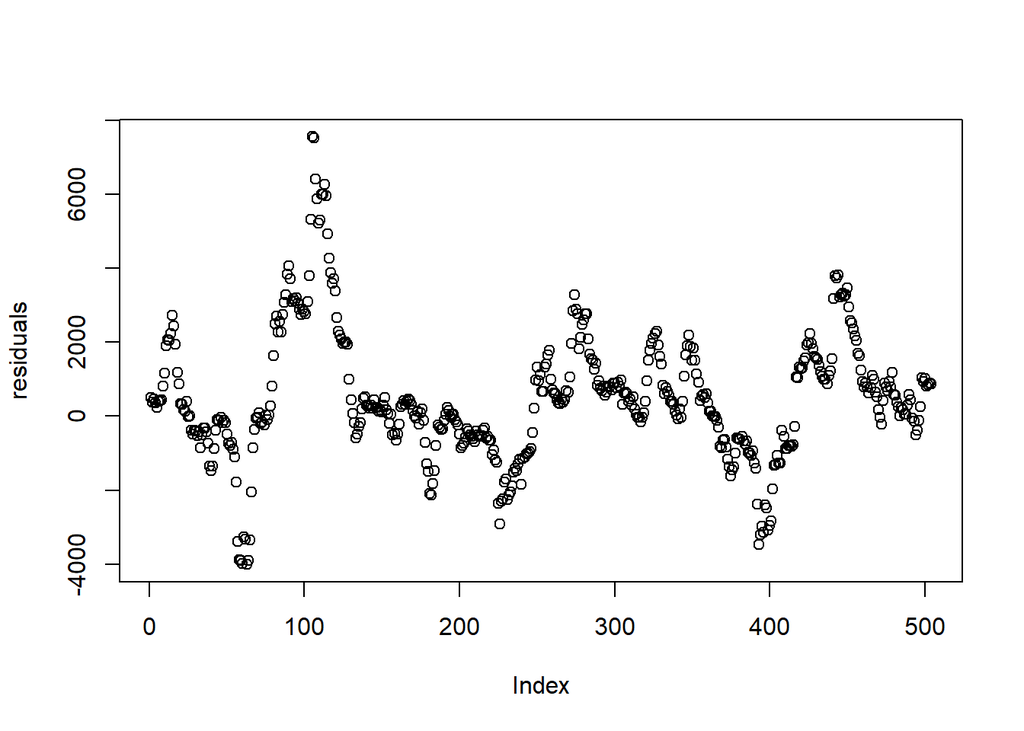

```r
plot(residuals)
```

```r
sum(abs(residuals/TestData$Consumption))*100/count(TestData)
```

```
##          n
## 1 4.032168
```

# PART C

First train and test data is splitted hourly by split function.

```r
TestHourly <- split(TestData,by="Saat")
TrainHourly <- split(TrainData,by="Saat")
```

Then for each hour, one linear model is constructed, predictions are made, and one MAPE value is calculated.

```r
linearHourlyModels <- vector(mode="list", length=24)
residuals <- vector(mode="list",length=24)
MAPES <- vector(length=24)
for(i in 1:24){
  linearHourlyModels[[i]] <-  lm(Consumption ~ Lag_48 + Lag_168 , data=TrainHourly[[i]])
  residuals[[i]] <- TestHourly[[i]]$Consumption -  predict.lm(linearHourlyModels[[i]],TestHourly[[i]])
  MAPES[[i]] <- sum(abs(residuals[[i]]/TestHourly[[i]]$Consumption))*100/21
}
```

MAPE values are then plotted hourly. We can easily see increasing MAPE values in the middle of the day.

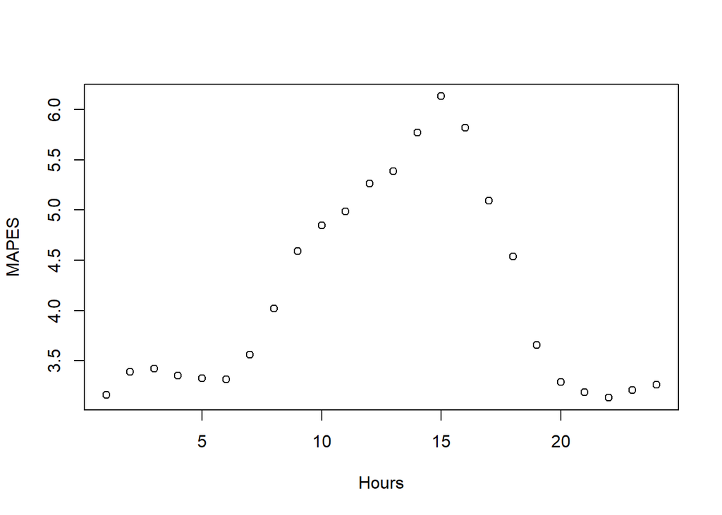

```r
Hours <-seq(1,24,1)
plot(Hours,MAPES)
```

# PART D

First wide format is obtained by using the spread function.

```r
OnlyData<-FullData[,1:3]
WideData<-spread(OnlyData,Saat,Consumption)
```

I then used the mean consumption for each hour and divide the consumption data by the mean consumption of that hour in order to scale the data accordingly. This will become helpful for lasso regression.

```r
meanvec <- vector(length=24)
#colnam <- colnames(WideData)

#for(i in 0:23){
# meanvec[i+1] <- mean(WideData$i)
#}

meanvec[1] <- mean(WideData$`0`)
meanvec[2] <- mean(WideData$`1`)
meanvec[3] <- mean(WideData$`2`)
meanvec[4] <- mean(WideData$`3`)
meanvec[5] <- mean(WideData$`4`)
meanvec[6] <- mean(WideData$`5`)
meanvec[7] <- mean(WideData$`6`)
meanvec[8] <- mean(WideData$`7`)
meanvec[9] <- mean(WideData$`8`)
meanvec[10] <- mean(WideData$`9`)
meanvec[11] <- mean(WideData$`10`)
meanvec[12] <- mean(WideData$`11`)
meanvec[13] <- mean(WideData$`12`)
meanvec[14] <- mean(WideData$`13`)
meanvec[15] <- mean(WideData$`14`)
meanvec[16] <- mean(WideData$`15`)
meanvec[17] <- mean(WideData$`16`)
meanvec[18] <- mean(WideData$`17`)
meanvec[19] <- mean(WideData$`18`)
meanvec[20] <- mean(WideData$`19`)
meanvec[21] <- mean(WideData$`20`)
meanvec[22] <- mean(WideData$`21`)
meanvec[23] <- mean(WideData$`22`)
meanvec[24] <- mean(WideData$`23`)

WideData <- cbind(WideData[,1],mapply('/', WideData[,2:25],meanvec))
```

Then lag values for 2 days and 1 week lag are calculated and added to the WideData. I changed the column names for those lag values. For the missing values at the start of the data I duplicated first two days and first seven days respectively for each lag calculation.

```r
First2days <- WideData[1:2,2:25]
First2days <- rbind(First2days,WideData[,2:25])
First2days <- First2days[1:1420]
colnames(First2days) <- c("200","201","202","203","204","205","206","207","208","209","210","211","212","213","214","215","216","217","218","219","220","221","222","223")
FirstWeek <- WideData[1:7,2:25]
FirstWeek <- rbind(FirstWeek,WideData[,2:25])
FirstWeek <- FirstWeek[1:1420]
colnames(FirstWeek) <- c("700","701","702","703","704","705","706","707","708","709","710","711","712","713","714","715","716","717","718","719","720","721","722","723")

WideData <- cbind(WideData,First2days)
WideData <- cbind(WideData,FirstWeek)
```

21 day test data is then seperated as usual.

```r
WideDataTrain <- WideData[1:1399,26:73]
WideDataTest <- WideData[1400:1420,26:73]
```

```r
#glmnet(WideDataTrain,WideData[1:1399]$"0")
```